# CRAVENS - Part 2 Excercies

Conoly Cravens (mcc4443)

8/3/2021

# **Question 1** Visual Story Telling Part 1: *Green Buildings*

FOR: Austin Real-Estate Developer

Unfortunately, your instincts were correct. The excel guru has made a couple of key errors while analyzing your real estate data:

## Mistake 1: Dropping leasing rates below 10%

From the boxplots below, you can see that most leasing rates are above 75%, and green buildings leasing rates are above 85%. So this calls me to question where the 10% came from. If you wanted to ‘cut off’ the outliars (all the dots in the boxplots), you would make drop any leasing rate below ~50%. However, would this lead to a better analysis?

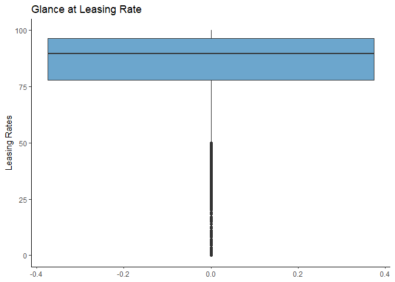

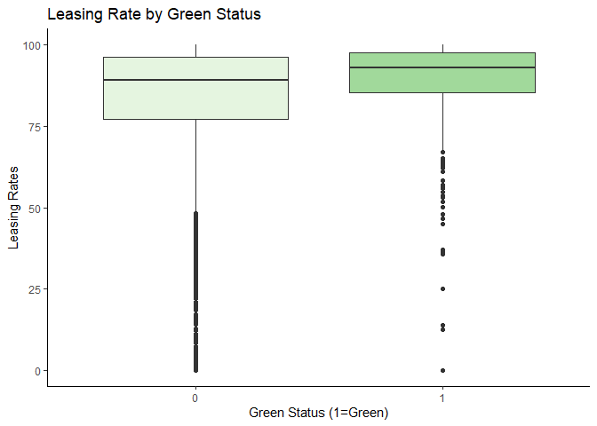

By examining the relationship between rent and leasing rate for both green and non green buildings (scatterplots below), we see there is nothing alarming between the relationship between rent and leasing rate for Green Buildings for leasing rates below 10%. So cutting the data does not make sense.

The theory of ‘weird buildings’ applies to several of non green buildings with ~0% leasing rate. We could consider dropping buildings with a 0% leasing rate, but again, I would still not cut off at the 10% margin.

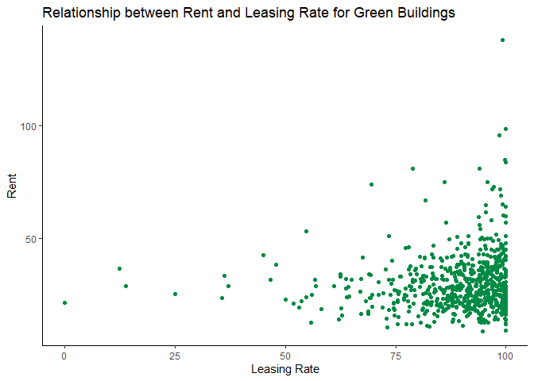

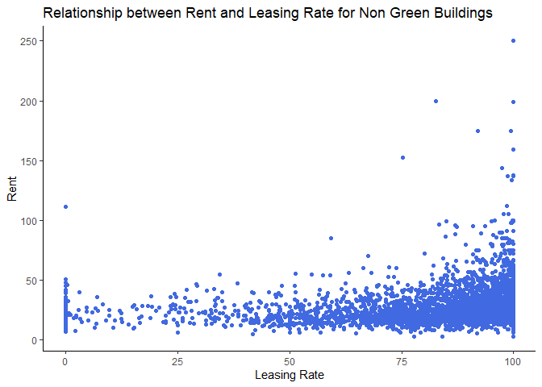

## Mistake 2: Using Median Market Rent

While the distribution of rent is very large with many outliars on the high side {see boxplots below}, using the median rent for each group does not take into account the many other variables that could also be impacting rent.

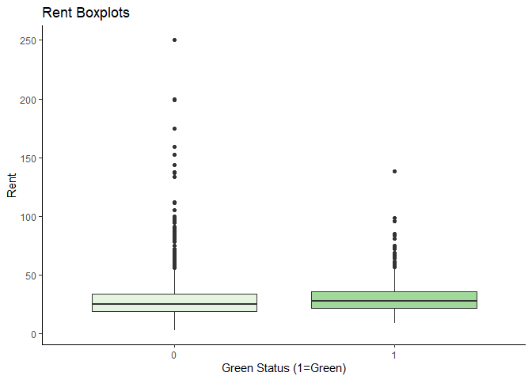

Facts we know about the new building:

- New Build (age = 0)
- Green Status in question
- 15 stories
- Location: East Cesar Chavez

### Factor in consideration: BUILDING CLASS

Another factor the guru did not consider was class. Off the bat, we see how there are a different proportion of buildings in each building class for green and non green buildings. To no surprise, most green buildings gall into Class A, the most desirable class. *I will assume if we build a green building, it will fall into the class A class based on this distribution.* Now how does class relate to rent?

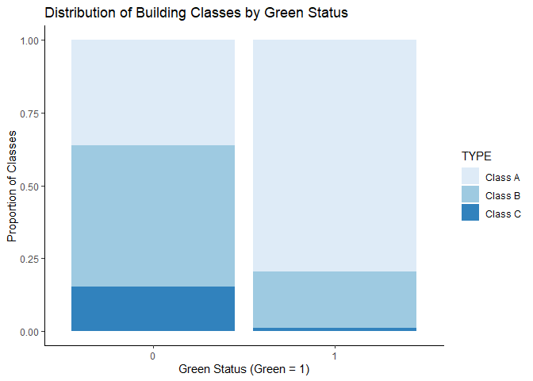

We can clearly see that class is related the rent, and additionally, the differences between green and non green buildings rent depends on the class of the building. *Assuming we would be a class A building, green and non green buildings will have about the same rent.*

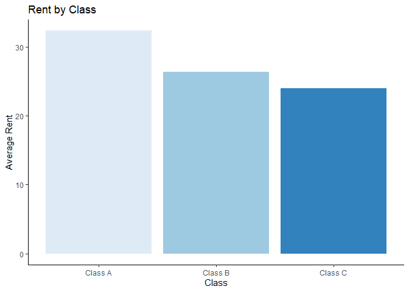

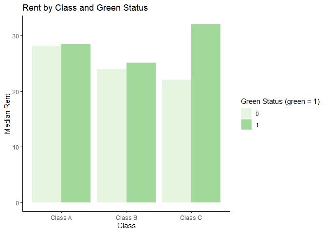

### Factor in consideration: NUMBER OF STORIES

The guru did not take into consideration how many stories the proposed building would have. Clearly the number of stories in a building effects rent, but more importantly for our sake, the difference between green and non green buildings varies. *For a 15 story building, green and non green buildings have almost identical mean rents.*

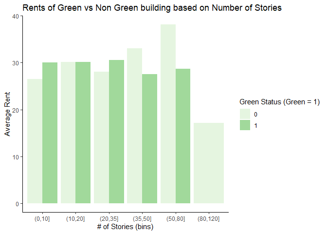

### Factor in consideration: AMENITIES

We also know about amentity status. *For our mixed-use building (assuming this means amenities will be provided), rent for green buildings may have a very small premium, but not much at all.*

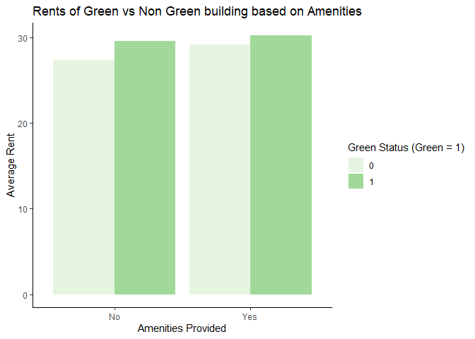

### Factor in consideration: AGE

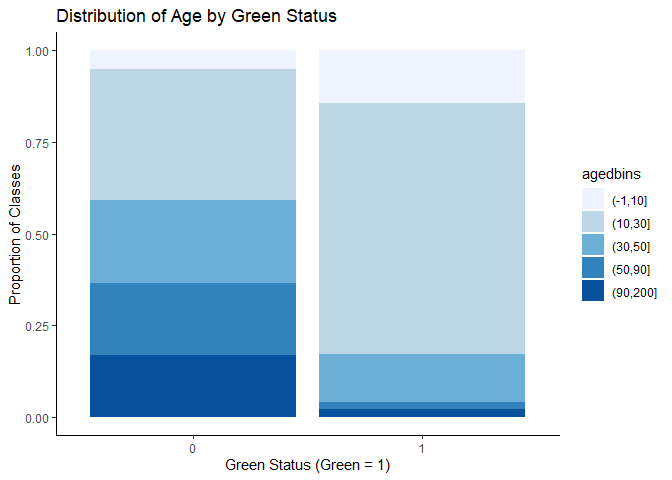

We see off the bat that green buildings appear to be out preforming non green buildings for older buildings. *For our newer building, non-green buildings have a premium*:

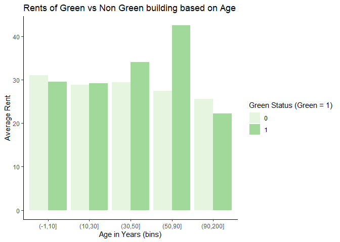

But then we looked into rennovation status and saw that green buildings have a premium on rennovated buildings. What is the difference between new buildings and rennovated buildings?

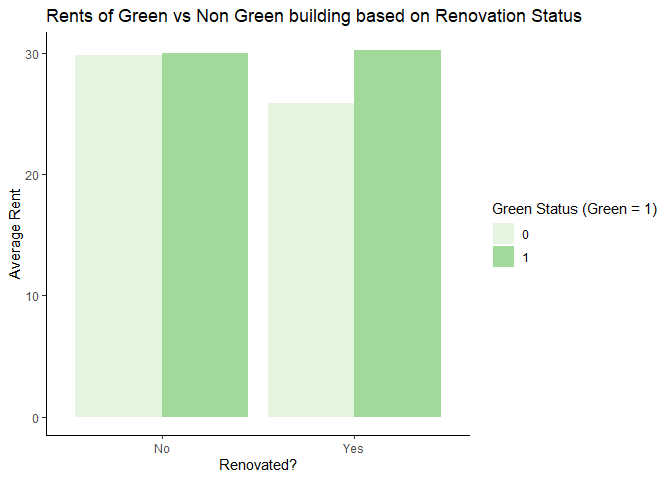

We then took a step back to see how age was related to rent for all buildings and we saw the following distribution:

[figure not shown]

Does age really not effect rent? This seems unlikely. There must be another factor at play here. Is there an area where the location is ideal but the buildings are older, such as downtown?

### Factor in consideration: LOCATION

One of the primary factors the excel guru did not take into consideration was location. In particular, how green buildings behave in their cluster.

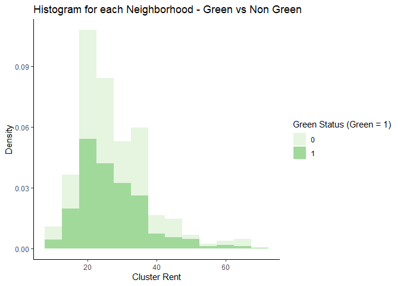

Depending on the ‘market rate’ or mean cluster rent for buildings near East Cesar Chavez (across form 1-35), the difference in rent for green and non green buildings may vary.But green buildings appear to have a premium for every group. **Location is a very important factor to consider.**

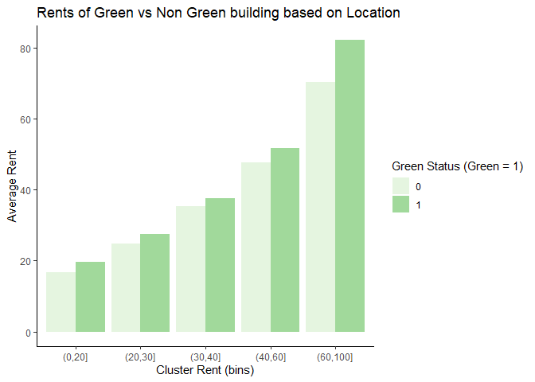

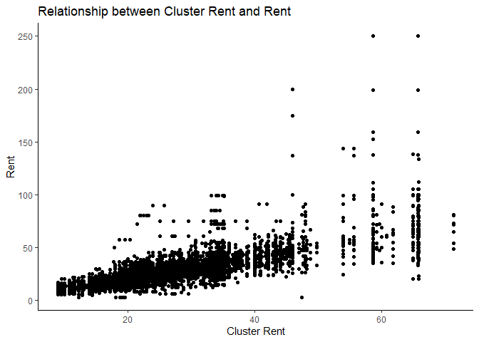

## Conclusion

I cannot happily agree with your excel guru. We saw the relationship between rent and a few of the 20+ predictors we have to work with within the data: *green status, class, stories, amenities, age / renovation status*. We also clearly saw while examining age, there must be confounding variable at play - potentially *location*?

So while considering each of these variables relationship independently, we also must consider how they are all working together:

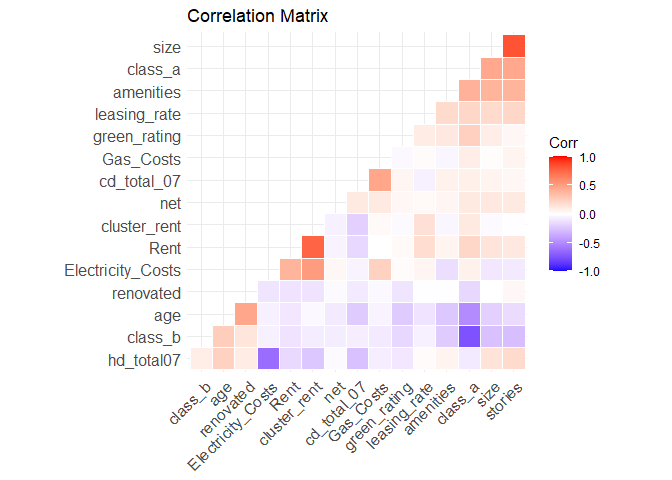

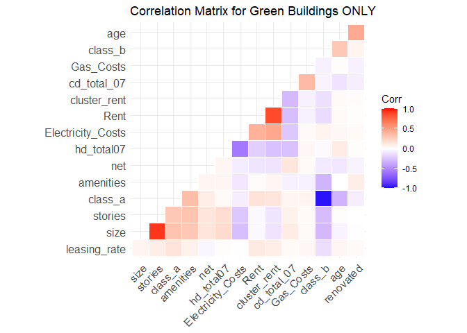

We do see a Cluster rent is clearly the most strongly correlated to rent, **therefore, I would highly recommend we perform a deep analysis of the surrounding area to get an idea of rent for both green and non buildings**.

But if I had to make a recommendation right now, I would say if you are looking for short-term gains, there would not be enough of a premium on a green building to make it worth your while (think about the class and age minimal or no gains). However, if we are looking to hold onto the property a green building may be worthwhile as we saw the price of green buildings upholds over the long term. `

# **Question 2** Visual Story Telling Part 2: *Flights at ABIA*

## Airline Analysis

### ‘Most Frequent Flyers’ (airline volume of flights)

**Southwest Airlines** (WN) has the most flights in and out of ABIA followed by *American Airlines*.

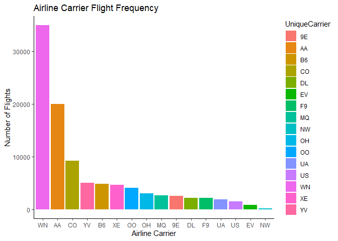

### Airlines with most Cancellations

First, we looked at cancelled flights distribution by the 3 options (A = carrier, B = weather, C = NAS, D = security). We can see that most flights are canceled due to weather or by airline. Assuming the weather cancellations effect each airline more or less evenly thoughout the year, we will continue to analyze cancellations for each airline using total cancellations.

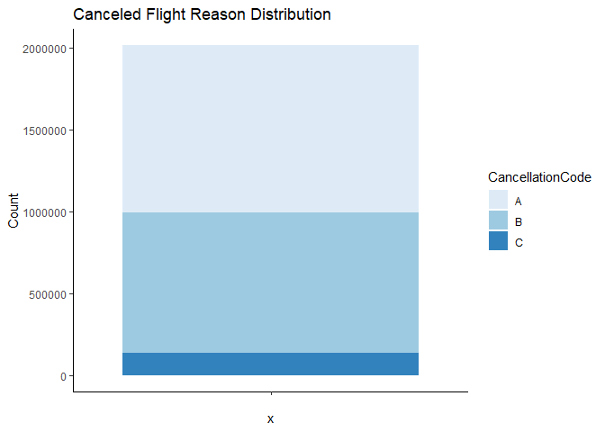

Since the number of flights each airline has in and out of ABIA, we used % of canceled flights as a better determinate for analyzing cancellation frequency. We see that Envoy Airlines (MQ) has the largest cancellation percentage (~6.4%). All other airlines are below 3%. While 6% is not ‘alarming’ per say, all people booking flights should be aware of Envoy’s cancellation rate.

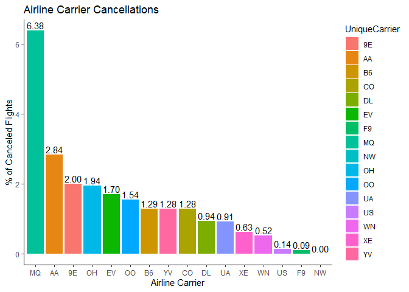

### Airlines with Delays

Aside from a cancelled flight, flyers has delayed flights more than anything. Let’s examine delays. To do so, we want to consider flight time as well as delay time - is a 20 minute delay for a 1 hour flight the same as a 5 hour flight? No! Again, we see Envoy Airlines (MQ) having the the longest delays.

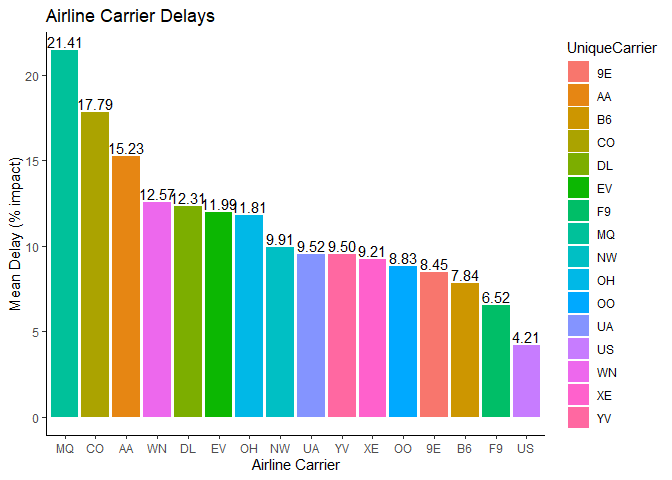

### Day of Week Delays

We see delays do not have the same impact by day of the week. Thursday and Friday have the longest delays.

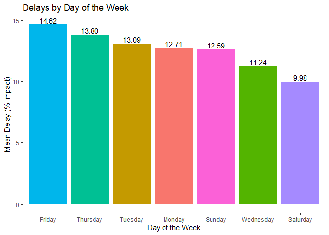

### Look at Day of Week Delays by Airlines

Now to combine those two insights, we broke down each airline with their day of week delays. Each plot goes from Monday on the left to Sunday on the far left. We can make suggestions on which airline to beware of based on the type of traveler:

- Weekend Traveler: Beware of Envoy Airlines (MQ), they have high impact delays on Thurday/ Fridays & Sundays
- Business Traveler: Beware of Continental Airline (CO), Northwest Airlines (NW), and even American Airlines

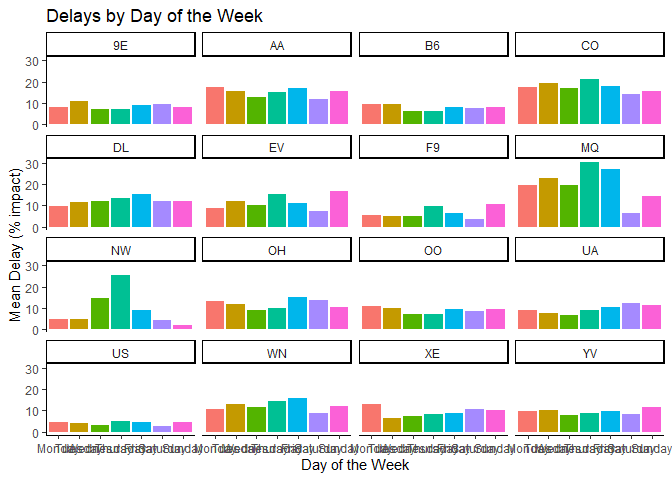

*A further explanation of time of day and Airline Delays would be carried out the same way. For the sake of concision, we will not demonstrate that process. However, similar findings were found - avoid Envoy (MQ) on the weekends (think mid-morning flights Thursday/ Friday & Sunday). Additionally for professionals (think early monring weekday flights), beware of Continental Airlines!*

## Locations

We can also see where ABIA flights typically go and come from:

### Flights coming to Austin

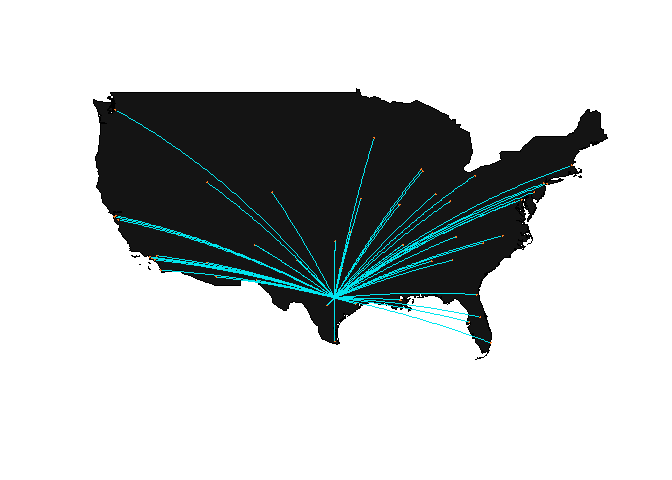

### Flights Leaving to Austin

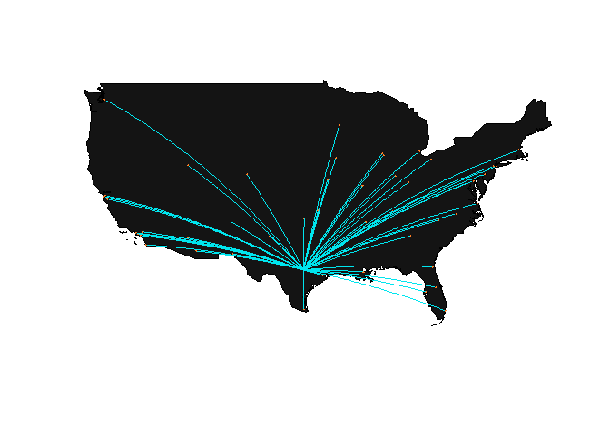

### Big Picture

- Green = Flights Arriving in Austin
- Red = Flights Departing from Austin

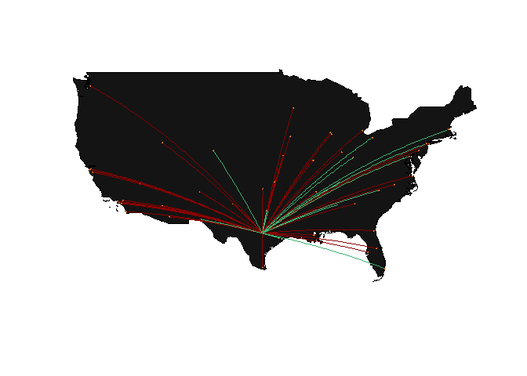

# **Question 3** Portfolio Modeling

We assessed three different portfolios VaR:

- **Income Focused Portfolio**
  - A portfolio made up of *5 EFTs* with high dividend payout.
- **Tech Portfolio**
  - A portfolio made up of *5 EFTs* focused on technology equities.
  - As a reminder, the tech industry is very volatile.
- **Balanced Portfolio**
  - A portfolio made up of *7 EFTs* focused on balanced and diversification.

## Income Focused Portfolio

The five EFTs:

- **SDIV** {Global Equities} - offer exposure to a basket of dividend-paying equities on a global scale
- **YLD** {High Yield Bonds} - provide “current income with diversified risk” by investing in companies with a “defensive quality bias.”
- **IJJ** {Mid Cap Value Equities} - exposure to mid-cap stocks that exhibit value characteristics and fine tune their domestic equity exposure
- **REZ** {Real Estate} – known for distributing 90% of their income to investors
- **SPYD** {Large Cap Blend Equities} – top 80 dividend-yielding companies in the S&P 500

A quick glimpse of the profit/loss histogram for the 5,000 bootstrap samples:

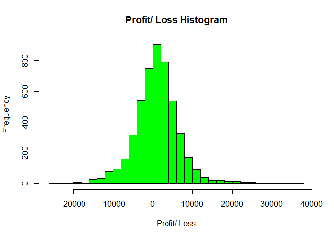

Using the 5,000 bootstrap samples, we estimate the the 4-week value at risk for the *income driven portfolio* at the 5% level to:

```
## [1] "$8,156"
```

## Tech Portfolio

- **SPYG** {Large Gap Growth Equities} - over 300 holdings and exposure is tilted most heavily towards technology
- **QQQ** {Large Gap Growth Equities} - useful as part of a buy-and-hold approach for investors looking to maintain a tilt towards the potentially volatile tech sector
- **XLK** {Technology Equities} - it invests in companies from all across the technology sector
- **TDIV** {Technology Equities} - First Trust NASDAQ Technology Dividend Index Fund
- **FXL** {Technology Equities} - looking for a more qualitative approach to the tech sector

A quick glimpse of the profit/loss histogram for the 5,000 bootstrap samples {note a couple of huge wins since the tech industry is so volitle}:

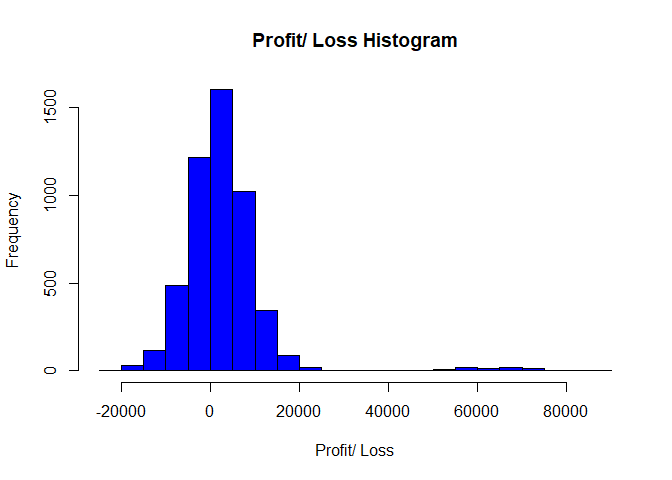

Using the 5,000 bootstrap samples, we estimate the the 4-week value at risk for the *tech portfolio* at the 5% level to:

```
## [1] "$8,205"
```

## Balanced Portfolio

- **RSP** {Large Cap Blend Equities} - considerably more balanced than other alternatives such as SPY, and a methodology that some investors believe will add value over the long haul
- **BSV** {Total Bond Markets} - great safe haven to park assets in volatile markets
- **RYT** {Technology Equities} - exposure that is considerably more balanced
- **SPEM** {Emerging Market Equities} - well-diversified option for long-term investors building a balanced portfolio
- **SCHF** {Foreign Large Cap Equities} - close to 1,000 individual holdings, this ETF brings immediate diversification
- **VXF** {All Cap Equities} - extremely diversified in small and mid caps
- **AOA** {Diversified Portfolio} - seeking an aggressive strategy that tilts towards equities and away from fixed income

A quick glimpse of the profit/loss histogram for the 5,000 bootstrap samples:

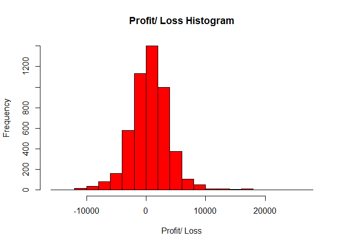

Using the 5,000 bootstrap samples, we estimate the the 4-week value at risk for the *Balanced portfolio* at the 5% level to:

```
## [1] "$4,451"
```

So in summary, we have three portfolios. One focused on dividend payout, one focused on tech (volatile industry), and another one with a well balanced portfolio. For each portfolio, we estimated the 4-week VaR at the 5% level:

```
##      Portfolio    VaR
## 1 Income-Drive $8,156
## 2         Tech $8,205
## 3     Balanced $4,451
```

To no surprise, the balanced portfolio has the lowest amount of risk for a 4-week (20 trading day) period. Tech and income-driven turn out to have about the same amount of risk.

# **Question 4** Market Segmentation

FOR: NutrientH20 Executives OBJECTIVE: Identify market segments that appear in your social-media audience

## Methodology: Kmeans Clustering

After some data exploration and fitting a variety of models, we determined that K-means clustering was an effective (and efficient) way to determine market segments.

### Determining the Optimal Number of Clusters (k)

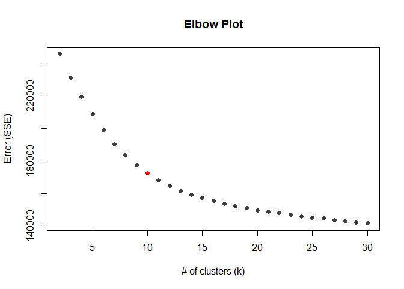

From the elbox plot, we determined that **10** clusters optimizes the bias-variance trade off in our error (slope from 10 -> 11 is less steap than the slope from 9 -> 10).

## Result

After dividing our followers into 10 segments, we get the following table of centers (conditional formatted to highlight the factors that each cluster scored well in).

|  | 1 | 2 | 3 | 4 | 5 | 6 | 7 | 8 | 9 | 10 |
| --- | --- | --- | --- | --- | --- | --- | --- | --- | --- | --- |
| current_events | 0.10914581 | 0.05848016 | -0.1977810 | 0.10629933 | 0.034542847 | 0.316328500 | 0.186429132 | -0.077951523 | 0.33235797 | -0.0254193582 |
| travel | 3.27190413 | -0.18542261 | -0.2263512 | -0.10176818 | 0.048679256 | 0.238104631 | -0.057760074 | -0.031582744 | -0.20185833 | -0.1569172296 |
| photo_sharing | -0.11137698 | -0.21574178 | -0.4192754 | -0.09574796 | -0.174684076 | -0.073458797 | 1.257802892 | -0.009980486 | 1.10547322 | -0.1171317611 |
| tv_film | -0.07173772 | -0.00575064 | -0.2118607 | -0.09321536 | -0.194493863 | 2.781838781 | -0.135118842 | 0.107052269 | -0.12401476 | -0.1395029923 |
| sports_fandom | -0.20726375 | 0.67118752 | -0.3212934 | 2.11490950 | -0.155953351 | -0.126612069 | -0.206660261 | -0.131180557 | -0.20041004 | -0.1935502056 |
| politics | 3.13063324 | 1.22750715 | -0.3023948 | -0.22390866 | -0.190805114 | -0.082009680 | -0.122715847 | -0.166187127 | -0.15074810 | -0.1920881061 |
| food | 0.16182288 | -0.15675589 | -0.3650572 | 1.87203059 | -0.121226702 | 0.142870547 | -0.190170650 | -0.098710261 | -0.30456109 | 0.4780753983 |
| family | -0.08219719 | 0.22953691 | -0.3113647 | 1.53239366 | 0.033554124 | -0.133051231 | 0.042846335 | 0.218305145 | -0.05049952 | -0.1008332847 |
| home_and_garden | 0.04388347 | 0.15904958 | -0.2048995 | 0.17431502 | 0.086104074 | 0.348989815 | 0.145956798 | 0.055075352 | 0.10846984 | 0.1535806743 |
| music | -0.04190820 | -0.08557909 | -0.2207815 | 0.02334339 | -0.015259800 | 0.971167965 | 0.537503715 | -0.056491035 | 0.14655760 | -0.0001695902 |
| news | 1.13789009 | 2.66037399 | -0.3111708 | -0.11073982 | -0.131201280 | 0.014095015 | -0.064270775 | -0.190055004 | -0.27347973 | -0.0699468911 |
| online_gaming | -0.15553666 | -0.12986855 | -0.2349684 | -0.07658452 | -0.011631837 | -0.174816112 | -0.015688979 | 3.591328301 | -0.16680430 | -0.1178383548 |
| shopping | -0.07427601 | -0.17779910 | -0.3907513 | -0.02292988 | -0.192007570 | 0.036162385 | 0.199371223 | -0.117605377 | 1.38412244 | -0.0636136271 |
| health_nutrition | -0.16121257 | -0.24360412 | -0.3078685 | -0.13755045 | -0.197874386 | -0.153173220 | -0.059152858 | -0.178755187 | -0.23420340 | 2.2416016645 |
| college_uni | -0.03834259 | -0.19933946 | -0.2547455 | -0.13144109 | -0.125144845 | 0.319614434 | -0.007490816 | 3.327887289 | -0.08702659 | -0.2112635232 |
| sports_playing | 0.04090674 | -0.08758388 | -0.2613880 | 0.11205967 | -0.176202123 | 0.099697127 | 0.201218663 | 2.163068433 | -0.03653960 | -0.0246004068 |
| cooking | -0.18827971 | -0.24130535 | -0.3234069 | -0.09608011 | -0.156156334 | -0.127553306 | 2.835033912 | -0.119923124 | -0.22608448 | 0.4162971978 |
| eco | 0.17199992 | -0.10401578 | -0.2787385 | 0.16792980 | 0.190421266 | 0.089757822 | 0.020099723 | -0.065956112 | 0.28043572 | 0.5747774678 |
| computers | 2.94554722 | -0.18978301 | -0.2652666 | 0.08301652 | 0.099437004 | -0.166922641 | 0.080135353 | -0.079289519 | -0.03861193 | -0.0885720956 |
| business | 0.54332109 | -0.11860750 | -0.2394405 | 0.11738548 | -0.152352723 | 0.336647885 | 0.234304130 | -0.096937484 | 0.34401672 | 0.0502804027 |
| outdoors | -0.04537119 | 0.29559536 | -0.3363297 | -0.07183751 | 0.237642118 | -0.098047424 | 0.022455618 | -0.138310971 | -0.25115567 | 1.7463144775 |
| crafts | 0.19280650 | -0.16529131 | -0.2948734 | 0.69778561 | 0.020629751 | 0.788822602 | 0.095682697 | 0.024182746 | 0.06888754 | 0.0873579483 |
| automotive | -0.13344136 | 2.58899421 | -0.3158703 | 0.11571656 | 0.127956124 | -0.232944689 | 0.016614991 | 0.059887522 | 0.06778716 | -0.1951588978 |
| art | -0.15993898 | -0.16520164 | -0.2397956 | -0.01966460 | -0.037595455 | 2.801091104 | 0.002341985 | 0.289501860 | -0.20751566 | -0.0640105596 |
| religion | 0.11777009 | -0.17916520 | -0.2986564 | 2.31519685 | -0.181605572 | 0.004152806 | -0.124590545 | -0.182245214 | -0.25021381 | -0.1548297146 |
| beauty | -0.18362257 | -0.18616351 | -0.2748303 | 0.32751589 | -0.077074345 | 0.004099199 | 2.680773249 | -0.224220907 | -0.18146690 | -0.2081397276 |
| parenting | 0.02354578 | 0.03494837 | -0.3290974 | 2.18071420 | 0.061159738 | -0.183408021 | -0.069356818 | -0.122939241 | -0.19871460 | -0.0869272261 |
| dating | 0.30690965 | -0.03440827 | -0.1800022 | 0.02787447 | 0.007539990 | -0.087134906 | 0.015965495 | -0.008810570 | 0.36154019 | 0.1779129089 |
| school | -0.10351228 | 0.01656593 | -0.3279260 | 1.70372772 | 0.002801984 | -0.045882464 | 0.166725756 | -0.214497007 | 0.11456148 | -0.1843845945 |
| personal_fitness | -0.14326485 | -0.23582040 | -0.3303525 | -0.09380323 | -0.079425378 | -0.158803880 | -0.035753996 | -0.181447042 | -0.18802745 | 2.1806483710 |
| fashion | -0.17521031 | -0.21791781 | -0.2918598 | 0.01999443 | -0.074797890 | -0.010845632 | 2.730643123 | -0.069802964 | -0.05662950 | -0.1139196947 |
| small_business | 0.41077931 | -0.15856783 | -0.2211531 | 0.08691185 | 0.431075230 | 0.781020747 | 0.167977868 | 0.105757151 | 0.18459313 | -0.1499010468 |
| bot | -0.14955067 | -0.17957302 | -0.1570436 | -0.06966897 | 4.956453864 | -0.107578038 | -0.105444145 | -0.109702927 | -0.15340703 | -0.1185267170 |
| unknown | -0.10029258 | -0.08160946 | -0.3933973 | -0.15160878 | 0.083966218 | 0.048079368 | 0.058670606 | -0.085460393 | 1.46129945 | -0.0979588792 |

## Cluster Analysis

### Cluster 1: Working Professionals

Cluster one had high scores in *travel*, *politics*, and *computers*, and medium scores in business, small business, and news. Based on these characteristics, we classify these are working professionals.

### Cluster 2: Middle Age Men

Cluster two had high scores in *politics*, *news*, and *automative*, and medium scores in sports fandom and outdoors. Based on these characteristics, we classify these are middle age men.

### Cluster 3: Uncharacterized

Cluster three had all negative scores, meaning no category stood out. This is the cluster of people we could not classify.

### Cluster 4: Parents

Cluster four had high scores in *family*, *religion*, *parenting*, *school*, *sports fandom*, and *food*. Based on these characteristics, we classify this segment as parents.

### Cluster 5: BOTs

Cluster five are the bots that were not initially filtered out.

### Cluster 6: Artists

Cluster six had high scores in *tv film* and *art*, and medium scores in music, craft, and small businesses. Based on these characteristics, we classify these as artists.

### Cluster 7: Young Women

Cluster seven had high scores in *cooking*, *beauty*, and *fashion*, and medium scores in photo sharing and music. Based on these characteristics, we classify these as young women

### Cluster 8: College Students

Cluster eight had high scores in *online gaming*, *college university*, and *sports playing*. Based on these characteristics, we classify these as college students.

### Cluster 9: Middle Aged Women Active on Computers

Cluster nine had high scores in *photo sharing*, *shopping*, and *unknown (combination of chatter and uncategorized*. Based on these characteristics, we classify these as middle age women active on their computers.